# Peekbank Item Demo

Martin Zettersten & the Peekbank Team

15 February, 2022

# Download peekbankr

If you haven’t downloaded peekbankr (https://github.com/langcog/peekbankr) yet, be sure to do so first by uncommenting the lines below.

```r
knitr::opts_chunk$set(cache = TRUE, arn = FALSE,warning=FALSE, message = FALSE,cache.lazy = FALSE)

# install.packages("remotes") # can also use devtools
# remotes::install_github("langcog/peekbankr")
```

# Preliminaries and data loading

Load packages. Since it takes a while to download and join the data, you probably want to just do that once, and then save the resulting dataset. Setting the parameter FIRST_TIME to FALSE after you run the script the first time allows you to bypass the data download process on subsequent runs. You can also use the most recent data file uploaded to GitHub.

```r
FIRST_TIME = FALSE # set to true first time to download data from DB

library(peekbankr)
library(tidyverse)
library(here)
library(lme4)
library(lmerTest)
#library(cowplot)
#theme_set(theme_cowplot())
```

The next steps demonstrate how to

1. Connect to the peekbank database
2. Pull individual tables using peekbankr functions (“get_[name_of_table]”). For details on the specific tables, including a codebook, see the peekbank documentation: https://peekbank.stanford.edu/docs/documentation/
3. Join these tables together to get a single tidy dataset in “long” format (each row is an observation at a particular timepoint)

```r
#get all of the tables you need
datasets <- get_datasets()
administrations <- get_administrations()
subjects <- get_subjects()
aoi_timepoints <- get_aoi_timepoints()
stimuli <- get_stimuli()
trial_types <- get_trial_types()
trials <- get_trials()

aoi_data_joined <- aoi_timepoints %>%
  right_join(administrations) %>%
  right_join(subjects) %>%
  right_join(trials) %>%
  right_join(trial_types) %>%
  right_join(datasets) %>%
  mutate(stimulus_id = target_id) %>% #just joining in the target properties. Add a second join here if the distractor info is needed too
  right_join(stimuli)

save(file = here("peekbank_items","data","aoi_data_joined.Rds"), aoi_data_joined)
```

# Load cached data

```r
load(file = here("peekbank_items","data","aoi_data_joined.Rds"))
```

# Average trial-level data

Goal here is to average looking performance for each trial across a critical window (t_min and t_max). We also set a threshold for how much looking data must be included in order for the trial to merit inclusion.

```r
#### PARAMETERS TO SET ####
#critical window dimensions roughly consistent with e.g., Swingley & Aslin, 2002
t_min <- 300
t_max <- 2000
#proportion missing trials threshold (any trial in which over half of the critical window missing is looking data is excluded )
max_prop_missing <- 0.5
#age bin size (number of months per bin)
age_bin_size <- 6
#add baseline window for computing baseline-corrected means
baseline_window <- c(-2000,0)
#minimum baseline duration in ms
min_baseline <- 500


by_trial_means <- aoi_data_joined %>%
  #restrict to english datasets (this is just because there are so few non-English datasets atm)
  filter(native_language == "eng") %>%
  #restrict age range
  filter(age > 12, age <= 60) %>%
  # familiar target items only %>%
  filter(stimulus_novelty == "familiar") %>%
  #window of analysis
  filter(t_norm >= t_min, t_norm <= t_max) %>%
  #bin ages (can adjust size of age bins here)
  mutate(age_binned = cut(age, seq(12,60,age_bin_size))) %>%
  rename(target_label = english_stimulus_label) %>%
  group_by(dataset_name,subject_id, trial_id, target_label,
           age, age_binned) %>%
  summarise(prop_target_looking = sum(aoi == "target", na.rm = TRUE) /
              (sum(aoi == "target", na.rm=TRUE) +
                 sum(aoi=="distractor", na.rm=TRUE)),
            prop_missing = mean(aoi %in% c("missing","other"), na.rm = TRUE)) %>%
  #remove trials with insufficient looking to target or distractor
  filter(prop_missing<=max_prop_missing)

#compute baseline looking (for baseline-corrected means)
by_trial_baseline <- aoi_data_joined %>%
  #restrict to english datasets (this is just because there are so few non-English datasets atm)
  filter(native_language == "eng") %>%
  #restrict age range
  filter(age > 12, age <= 60) %>%
  # familiar target items only %>%
  filter(stimulus_novelty == "familiar") %>%
  #window of analysis
  filter(t_norm >= baseline_window[1], t_norm <= baseline_window[2]) %>%
  #bin ages (can adjust size of age bins here)
  mutate(age_binned = cut(age, seq(12,60,age_bin_size))) %>%
  rename(target_label = english_stimulus_label) %>%
  group_by(dataset_name,subject_id, trial_id, target_label,
           age, age_binned) %>%
  summarise(
   baseline_n=n(),
   baseline_ms=baseline_n*25,
    baseline_looking = sum(aoi == "target", na.rm = TRUE) /
              (sum(aoi == "target", na.rm=TRUE) +
                 sum(aoi=="distractor", na.rm=TRUE)),
            prop_baseline_missing = mean(aoi %in% c("missing","other"), na.rm = TRUE)) %>%
  #remove trials with insufficient looking to target or distractor
  filter(prop_baseline_missing<=max_prop_missing& baseline_ms>=500)

#combine
by_trial_target_means <- by_trial_means %>%
  left_join(by_trial_baseline) %>%
  mutate(corrected_target_looking=prop_target_looking-baseline_looking)
```

# Average within subjects, by-item and by-dataset

One could consider excluding participants based on the number of trials a participant contributes overall here.

```r
by_subj_item_means <- by_trial_target_means %>%
  group_by(dataset_name,subject_id, target_label,
           age, age_binned) %>%
  summarise(
    trial_num=n(),
    avg_target_looking = mean(prop_target_looking,na.rm=TRUE),
    avg_corrected_target_looking=mean(corrected_target_looking,na.rm=TRUE)
  )
```

# Average across subjects - by item, dataset and age bin

```r
by_item_means <- by_subj_item_means %>%
  group_by(dataset_name, target_label,age_binned) %>%
  summarise(
    subj_n=n(),
    target_looking = mean(avg_target_looking,na.rm=TRUE),
    corrected_looking = mean(avg_corrected_target_looking,na.rm=TRUE)
  )
```

# Mega Plot of items (collapsing across age & dataset)

Note that because this collapses across age, some items might be showing higher preformance because we only have observations for older children (who will typically do better overall).

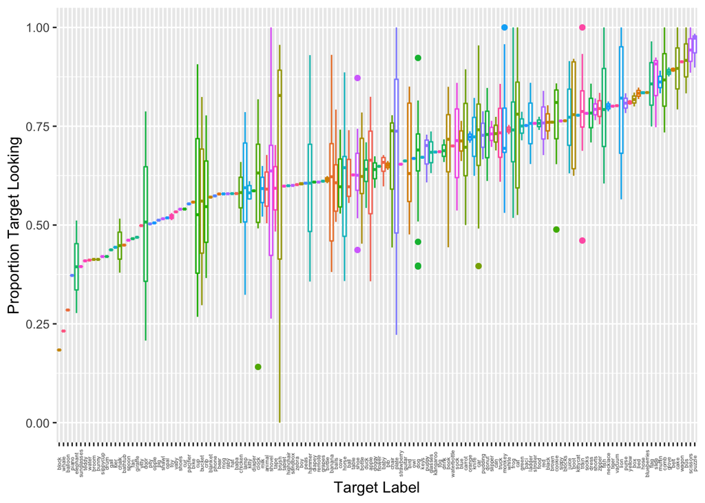

```r
ggplot(by_item_means,aes(reorder(target_label,target_looking,mean),target_looking,color=target_label))+
  geom_boxplot()+
  #geom_point()+
  theme(legend.position="none")+
  theme(axis.text.x=element_text(angle=90,size=4,vjust=0.5))+
  xlab("Target Label")+
  ylab("Proportion Target Looking")
```

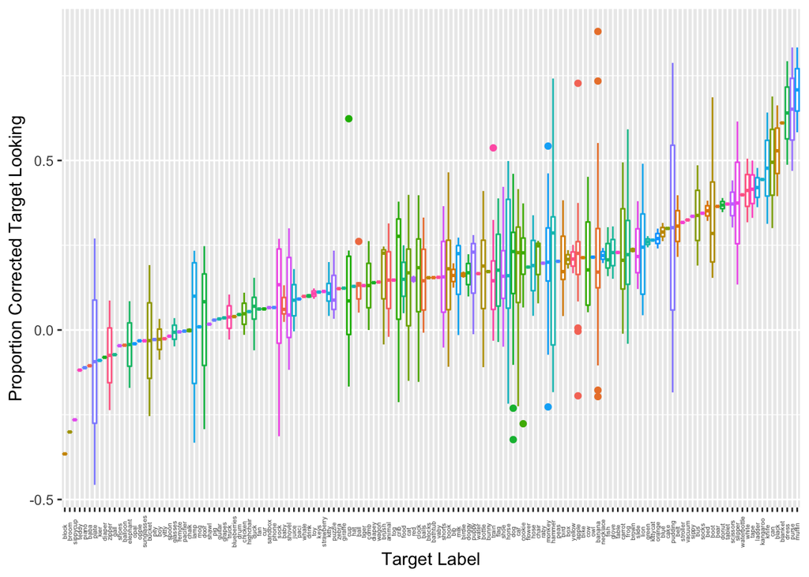

```r
ggplot(filter(by_item_means,!is.na(corrected_looking)),aes(reorder(target_label,corrected_looking,mean),corrected_looking,color=target_label))+
  geom_boxplot()+
  #geom_point()+
  theme(legend.position="none")+
  theme(axis.text.x=element_text(angle=90,size=4,vjust=0.5))+
  xlab("Target Label")+
  ylab("Proportion Corrected Target Looking")
```

# Mega Plot of items by age and dataset

Inspect average target looking for items that appear in multiple datasets (appears in at least >1 dataset) by age bin.

Each colored dot represents average looking to target for a given item within a specific dataset.

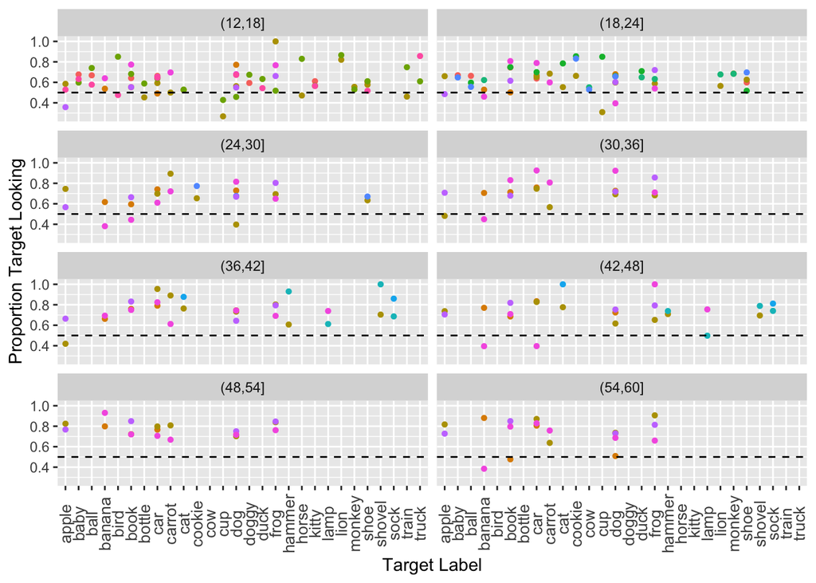

```r
by_item_means_across_dataset <- by_item_means %>%
  group_by(age_binned,target_label) %>%
  summarize(
    dataset_num=n(),
    prop_target_looking=mean(target_looking,na.rm=TRUE),
    corrected_target_looking=mean(corrected_looking,na.rm=TRUE)
  )

by_item_means <- by_item_means %>%
  left_join(select(by_item_means_across_dataset,-prop_target_looking,-corrected_target_looking))


ggplot(filter(by_item_means,dataset_num>1),aes(target_label,target_looking,fill=dataset_name,color=dataset_name))+
  geom_dotplot(binaxis="y",stackdir="center",dotsize=2)+
  theme(legend.position="none")+
  theme(axis.text.x=element_text(angle=90,vjust=0.5,size=10))+
  facet_wrap(~age_binned,nrow=4)+
  geom_hline(yintercept=0.5,linetype="dashed")+
  xlab("Target Label")+
  ylab("Proportion Target Looking")
```

## Item Accuracy within specific age ranges

### 12-18-month-olds

Focusing on (ordered) item accuracy just for infants in the 12-18 month age range, appearing in more than one dataset

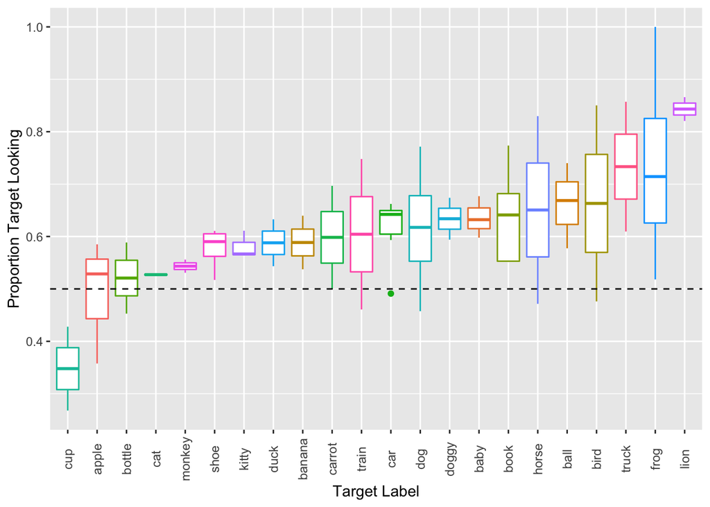

```r
ggplot(filter(by_item_means,age_binned=="(12,18]"&dataset_num>1),aes(reorder(target_label,target_looking,mean),target_looking,color=target_label))+
  geom_boxplot()+
  #geom_point()+
  theme(legend.position="none")+
  theme(axis.text.x=element_text(angle=90,size=9,vjust=0.5))+
  xlab("Target Label")+
  ylab("Proportion Target Looking")+
  geom_hline(yintercept=0.5,linetype="dashed")
```

Baseline-corrected target accuracy

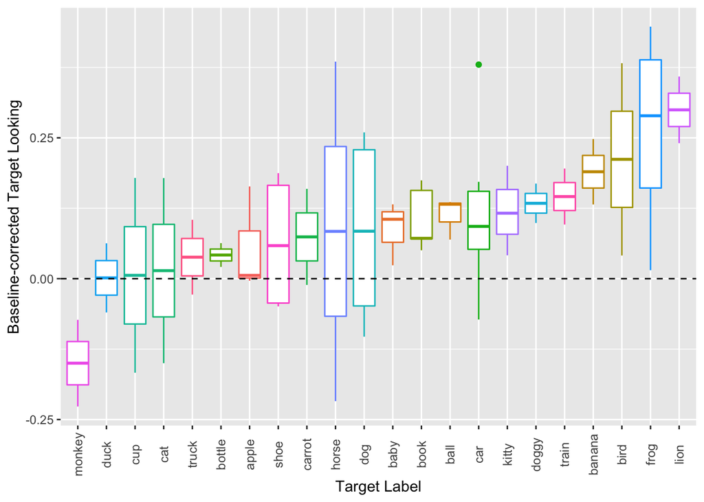

```r
ggplot(filter(by_item_means,age_binned=="(12,18]"&dataset_num>1&!is.na(corrected_looking)),aes(reorder(target_label,corrected_looking,mean),corrected_looking,color=target_label))+
  geom_boxplot()+
  #geom_point()+
  theme(legend.position="none")+
  theme(axis.text.x=element_text(angle=90,size=9,vjust=0.5))+
  xlab("Target Label")+
  ylab("Baseline-corrected Target Looking")+
  geom_hline(yintercept=0,linetype="dashed")
```

### 18-24-months-olds

Focusing on (ordered) item accuracy just for infants in the 18-24 month age range, appearing in more than one dataset

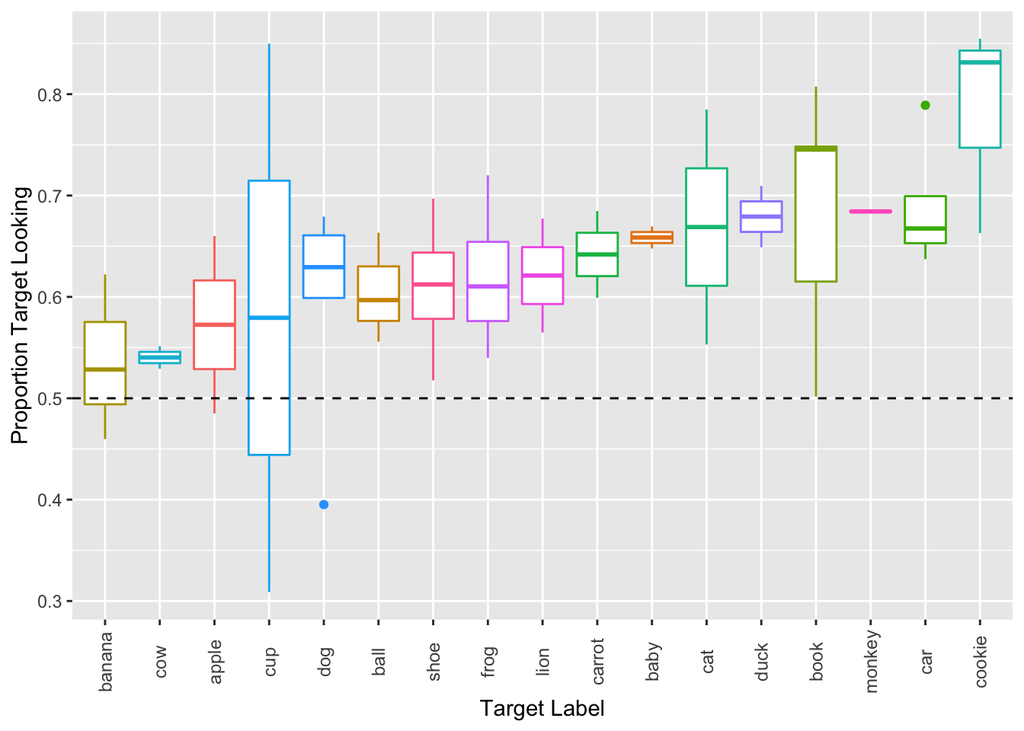

```r
ggplot(filter(by_item_means,age_binned=="(18,24]"&dataset_num>1),aes(reorder(target_label,target_looking,mean),target_looking,color=target_label))+
  geom_boxplot()+
  #geom_point()+
  theme(legend.position="none")+
  theme(axis.text.x=element_text(angle=90,size=9,vjust=0.5))+
  xlab("Target Label")+
  ylab("Proportion Target Looking")+
  geom_hline(yintercept=0.5,linetype="dashed")
```

Baseline-corrected target accuracy

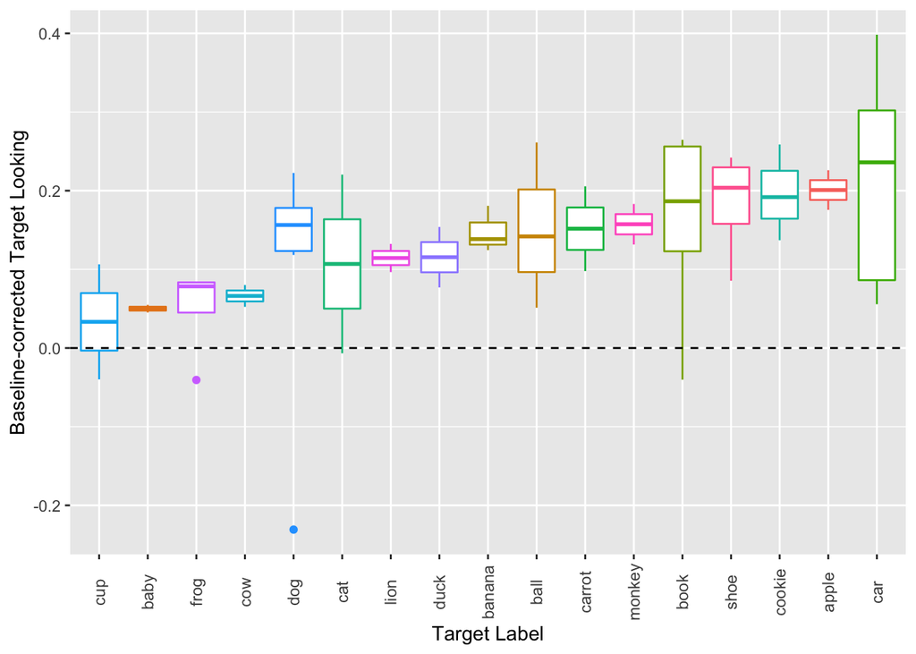

```r
ggplot(filter(by_item_means,age_binned=="(18,24]"&dataset_num>1&!is.na(corrected_looking)),aes(reorder(target_label,corrected_looking,mean),corrected_looking,color=target_label))+
  geom_boxplot()+
  #geom_point()+
  theme(legend.position="none")+
  theme(axis.text.x=element_text(angle=90,size=9,vjust=0.5))+
  xlab("Target Label")+
  ylab("Baseline-corrected Target Looking")+
  geom_hline(yintercept=0,linetype="dashed")
```

### 24-30-months-olds

Focusing on (ordered) item accuracy just for infants in the 24-30 month age range, appearing in more than one dataset

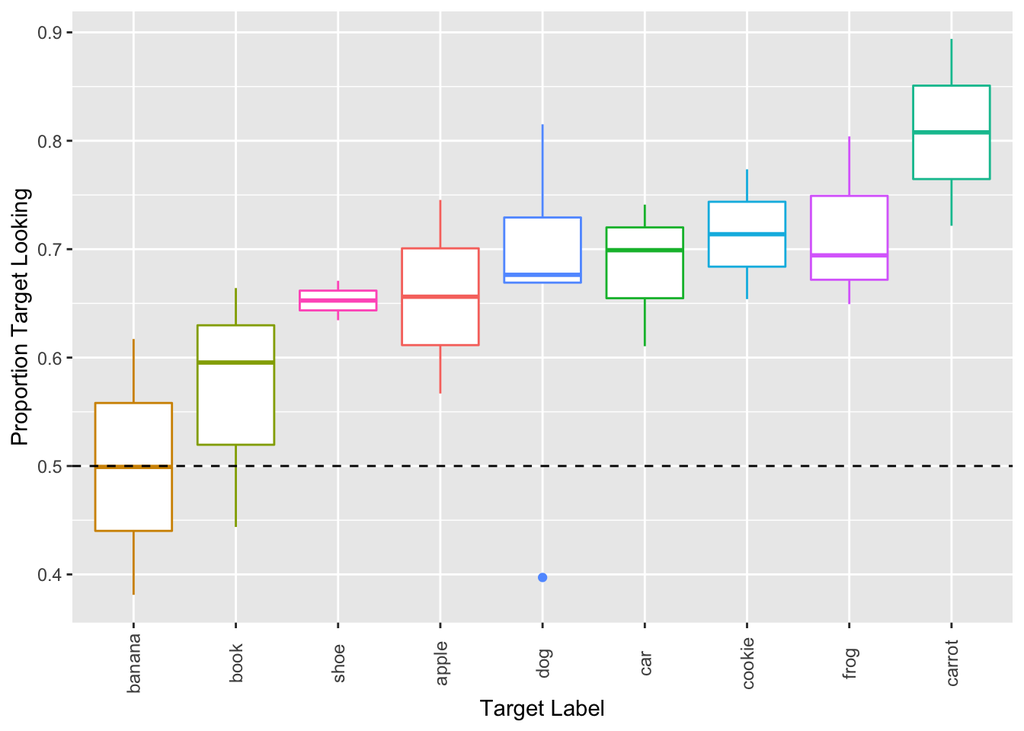

```r
ggplot(filter(by_item_means,age_binned=="(24,30]"&dataset_num>1),aes(reorder(target_label,target_looking,mean),target_looking,color=target_label))+
  geom_boxplot()+
  #geom_point()+
  theme(legend.position="none")+
  theme(axis.text.x=element_text(angle=90,size=9,vjust=0.5))+
  xlab("Target Label")+
  ylab("Proportion Target Looking")+
  geom_hline(yintercept=0.5,linetype="dashed")
```

Baseline-corrected accuracy

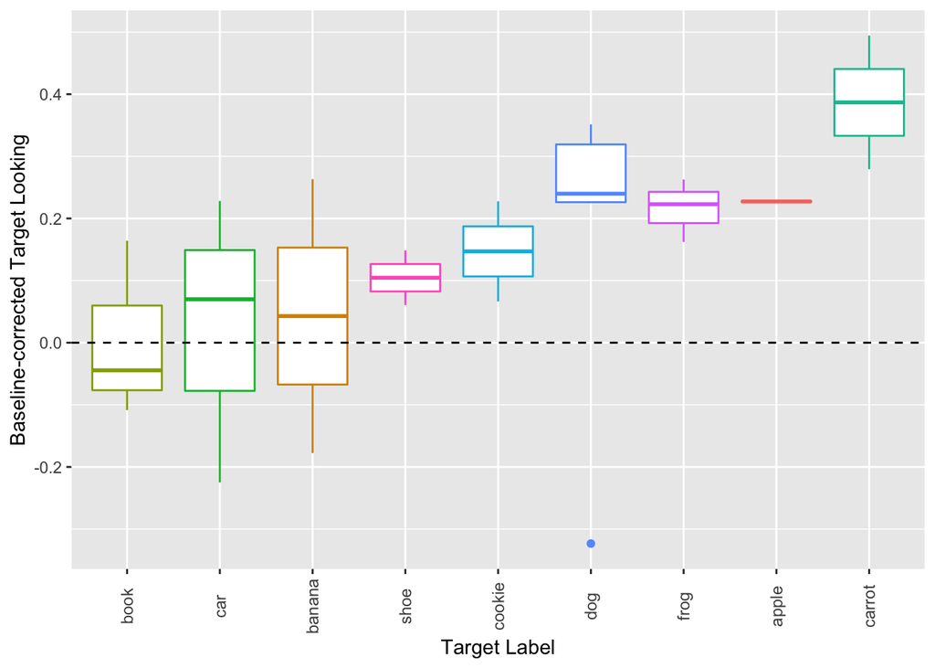

```r
ggplot(filter(by_item_means,age_binned=="(24,30]"&dataset_num>1&!is.na(corrected_looking)),aes(reorder(target_label,corrected_looking,mean),corrected_looking,color=target_label))+
  geom_boxplot()+
  #geom_point()+
  theme(legend.position="none")+
  theme(axis.text.x=element_text(angle=90,size=9,vjust=0.5))+
  xlab("Target Label")+
  ylab("Baseline-corrected Target Looking")+
  geom_hline(yintercept=0,linetype="dashed")
```

### 30-36-months-olds

Focusing on (ordered) item accuracy just for infants in the 30-36 month age range, appearing in more than one dataset

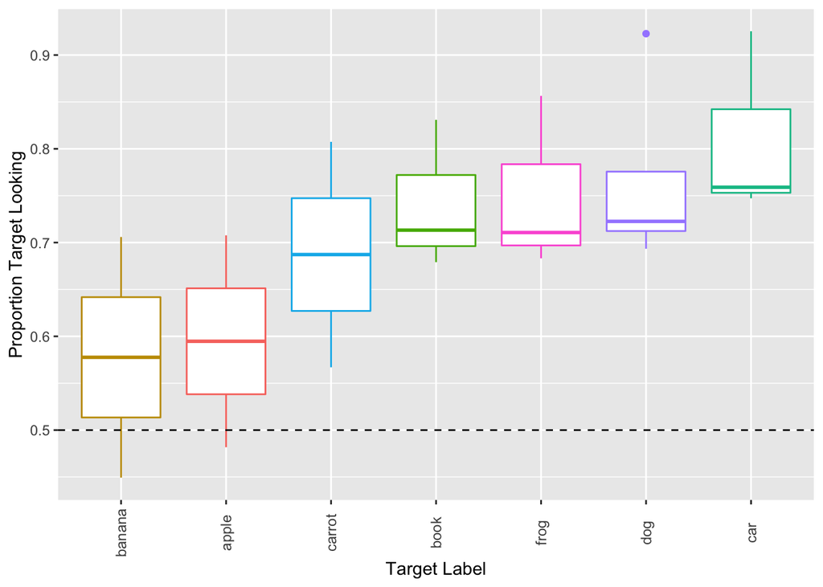

```r
ggplot(filter(by_item_means,age_binned=="(30,36]"&dataset_num>1),aes(reorder(target_label,target_looking,mean),target_looking,color=target_label))+
  geom_boxplot()+
  #geom_point()+
  theme(legend.position="none")+
  theme(axis.text.x=element_text(angle=90,size=9,vjust=0.5))+
  xlab("Target Label")+
  ylab("Proportion Target Looking")+
  geom_hline(yintercept=0.5,linetype="dashed")
```

Baseline-corrected accuracy

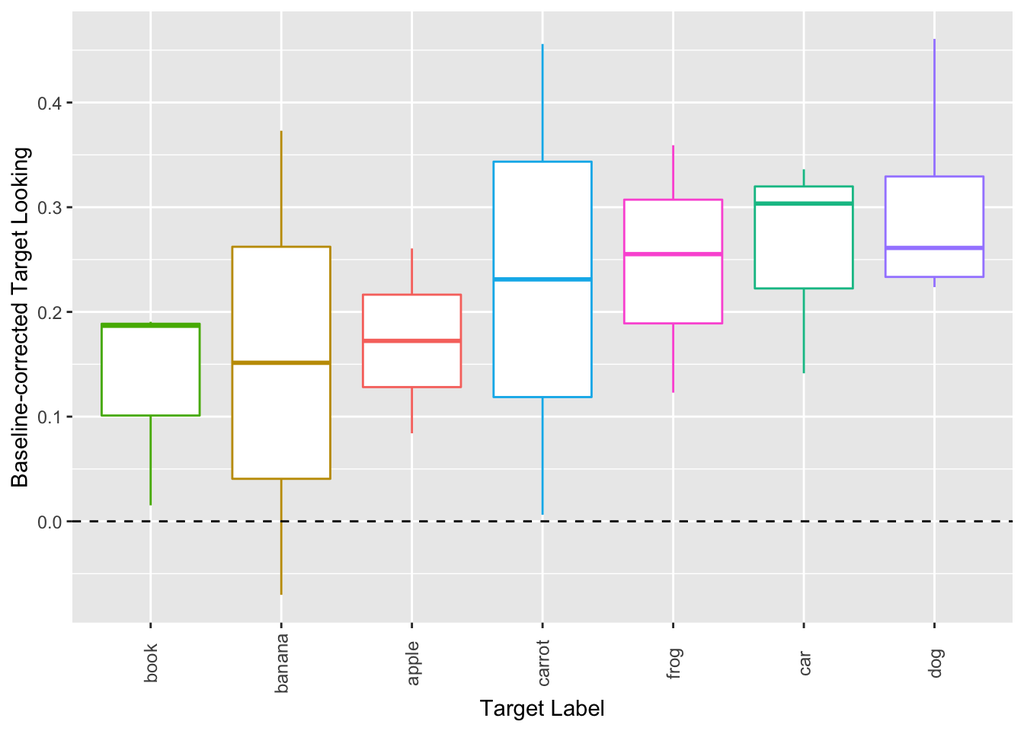

```r
ggplot(filter(by_item_means,age_binned=="(30,36]"&dataset_num>1&!is.na(corrected_looking)),aes(reorder(target_label,corrected_looking,mean),corrected_looking,color=target_label))+
  geom_boxplot()+
  #geom_point()+
  theme(legend.position="none")+
  theme(axis.text.x=element_text(angle=90,size=9,vjust=0.5))+
  xlab("Target Label")+
  ylab("Baseline-corrected Target Looking")+
  geom_hline(yintercept=0,linetype="dashed")
```

## Predict from AOA

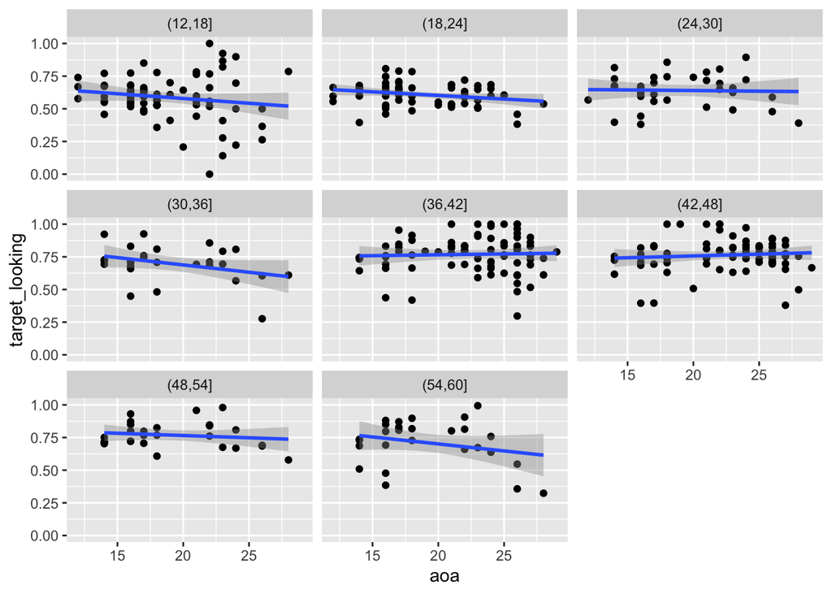

```r
aoas <- read_csv(here("peekbank_items","data","aoas_wordbank_ws_produces.csv"))

by_item_means <- left_join(by_item_means,aoas)

ggplot(by_item_means,aes(aoa,target_looking))+
  geom_point()+
  geom_smooth(method="lm")+
  facet_wrap(~age_binned)
```

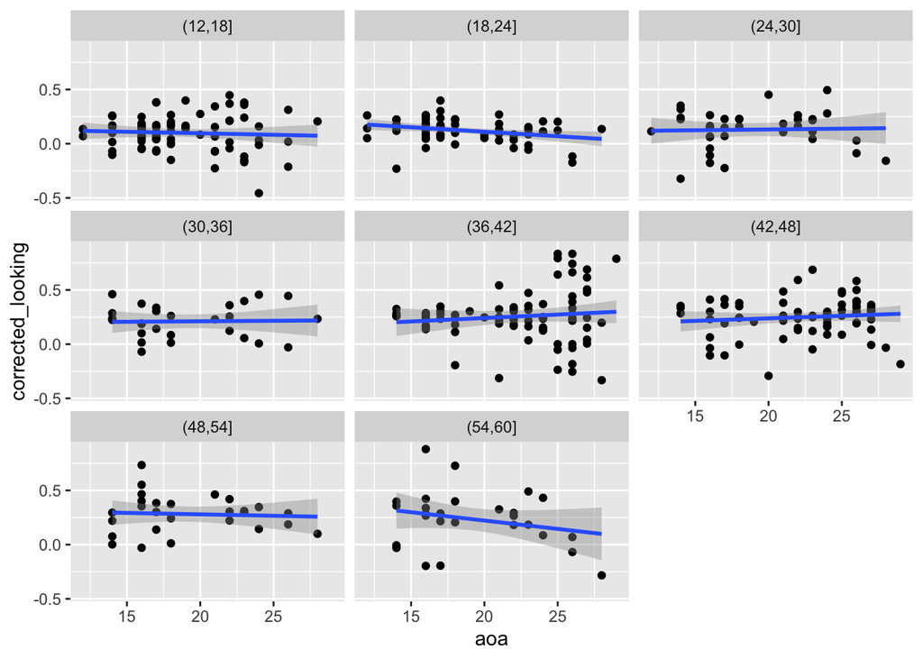

```r
ggplot(by_item_means,aes(aoa,corrected_looking))+
  geom_point()+
  geom_smooth(method="lm")+
  facet_wrap(~age_binned)
```